# ARodriguez_ProjectFullCodeNB_EasyVisa

# **Bivariate Analysis**

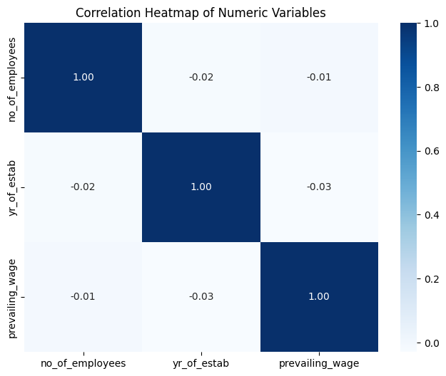

```python
# Selecting numeric columns
numeric_cols = data.select_dtypes(include=['int64', 'float64'])
numeric_cols.head()

# Computing correlation matrix
corr = numeric_cols.corr()
corr

# Plotting a heatmap
plt.figure(figsize=(8,6))
sns.heatmap(corr, annot=True, cmap='Blues', fmt=".2f")
plt.title("Correlation Heatmap of Numeric Variables")
plt.show()
```

- There are no significant correlations between the numerical values.

**continent vs prevailing_wage**

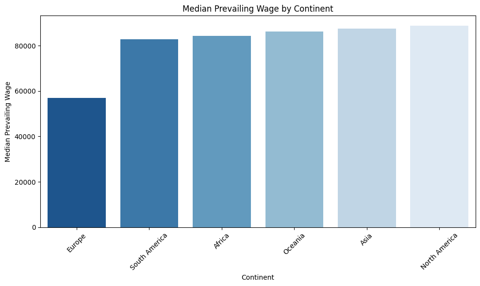

```python
# compute median wage per continent
continent_wage = data.groupby("continent")["prevailing_wage"].median().reset_index()

# sort by wage
continent_wage = continent_wage.sort_values(by="prevailing_wage", ascending=True)

plt.figure(figsize=(10,6))
sns.barplot(
    data=continent_wage,
    x="continent",
    y="prevailing_wage",
    palette="Blues_r"
)

plt.title("Median Prevailing Wage by Continent")
plt.xlabel("Continent")
plt.ylabel("Median Prevailing Wage")
plt.xticks(rotation=45)
plt.tight_layout()
plt.show()
```

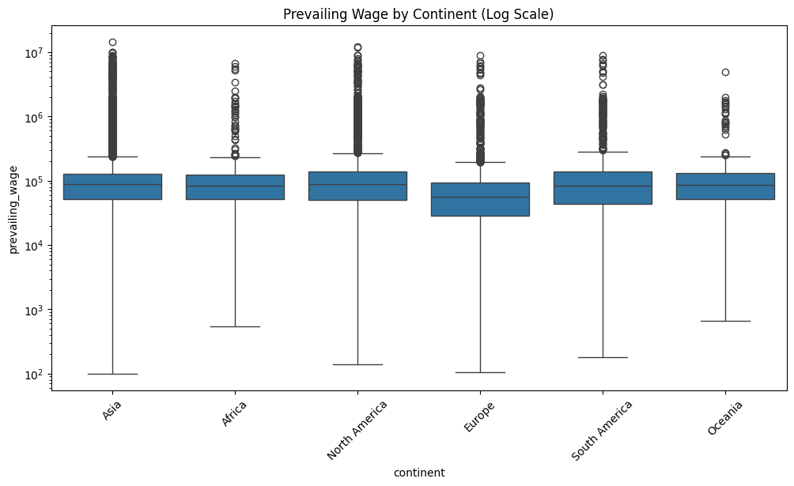

```python
# Calling log transformed boxplot
plt.figure(figsize=(12,6))
sns.boxplot(x="continent", y="prevailing_wage", data=data)
plt.yscale("log")
plt.title("Prevailing Wage by Continent (Log Scale)")
plt.xticks(rotation=45)
plt.show()
```

**region_of_employment vs prevailing wage**

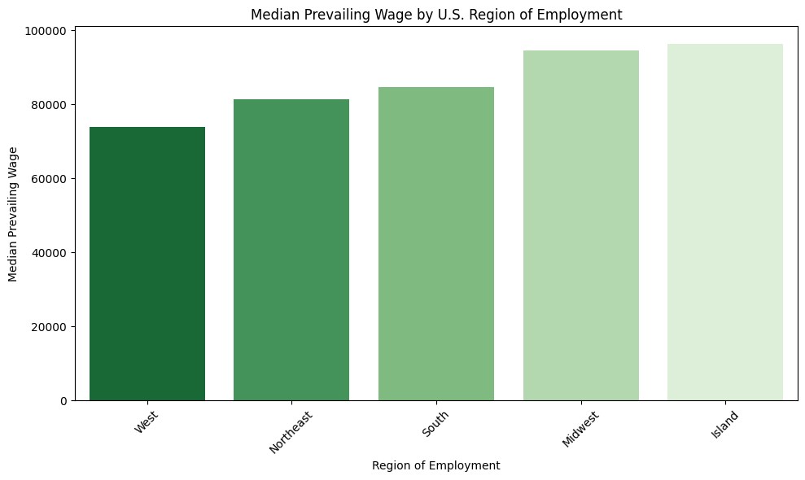

```python
# Compute median wage per region
region_wage = data.groupby("region_of_employment")["prevailing_wage"].median().reset_index()

# Sort for better visualization
region_wage = region_wage.sort_values(by="prevailing_wage", ascending=True)

# Creating barplot
plt.figure(figsize=(10,6))
sns.barplot(
    data=region_wage,
    x="region_of_employment",
    y="prevailing_wage",
    palette="Greens_r"
)

plt.title("Median Prevailing Wage by U.S. Region of Employment")
plt.xlabel("Region of Employment")
plt.ylabel("Median Prevailing Wage")
plt.xticks(rotation=45)
plt.tight_layout()
plt.show()
```

**education_of_employee vs prevailing wage**

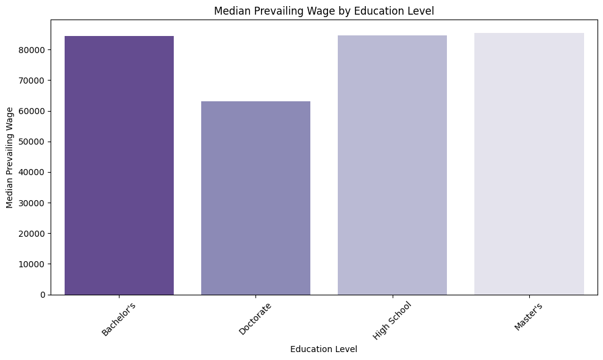

```python
# Compute median wage per education level
edu_wage = data.groupby("education_of_employee")["prevailing_wage"].median().reset_index()

# Sort for better visualization
edu_wage = edu_wage.sort_values("education_of_employee")

# Create barplot
plt.figure(figsize=(10,6))
sns.barplot(
    data=edu_wage,
    x="education_of_employee",
    y="prevailing_wage",
    palette="Purples_r"
)

plt.title("Median Prevailing Wage by Education Level")
plt.xlabel("Education Level")
plt.ylabel("Median Prevailing Wage")
plt.xticks(rotation=45)
plt.tight_layout()
plt.show()
```

# **Data Pre-processing**

```python
# Creating new version
data1 = data.copy()
```

```python
# Drop bins made earlier
data1 = data.drop(columns=['wage_bin', 'company_size'], errors='ignore')
```

```python
# Checking work
data1.head()
```

|  | continent | education_of_employee | has_job_experience | requires_job_training | no_of_employees | yr_of_estab | region_of_employment | prevailing_wage | unit_of_wage | full_time_position | case_status |
| --- | --- | --- | --- | --- | --- | --- | --- | --- | --- | --- | --- |
| 0 | Asia | High School | N | N | 14513 | 2007 | West | 1231782.032 | Hour | Y | Denied |
| 1 | Asia | Master's | Y | N | 2412 | 2002 | Northeast | 83425.650 | Year | Y | Certified |
| 2 | Asia | Bachelor's | N | Y | 44444 | 2008 | West | 122996.860 | Year | Y | Denied |
| 3 | Asia | Bachelor's | N | N | 98 | 1897 | West | 83434.030 | Year | Y | Denied |
| 4 | Africa | Master's | Y | N | 1082 | 2005 | South | 149907.390 | Year | Y | Certified |

```python
# Set X and y variables
X = data1.drop(["case_status"], axis=1)
y = data1["case_status"].apply(lambda x: 1 if x == "Certified" else 0)
```

```python
# Splitting data into training, validation and test set:
# first we split data into 2 parts, say temporary and test

X_temp, X_test, y_temp, y_test = train_test_split(
    X, y, test_size=0.2, random_state=1, stratify=y
)

# then we split the temporary set into train and validation

X_train, X_val, y_train, y_val = train_test_split(
    X_temp, y_temp, test_size=0.25, random_state=1, stratify=y_temp
)
print(X_train.shape, X_val.shape, X_test.shape)
```

```
(15288, 10) (5096, 10) (5096, 10)
```

```python
# Print results
print("Number of rows in train data =", X_train.shape[0])
print("Number of rows in validation data =", X_val.shape[0])
print("Number of rows in test data =", X_test.shape[0])
```

```
Number of rows in train data = 15288
Number of rows in validation data = 5096
Number of rows in test data = 5096
```

```python
# Create dummy variables
X_train = pd.get_dummies(X_train, drop_first=True)
X_train = X_train.astype(float)
y_train = y_train.astype(int)

X_val = pd.get_dummies(X_val, drop_first=True)
X_val = X_val.astype(float)
y_val = y_val.astype(int)

X_test = pd.get_dummies(X_test, drop_first=True)
X_test = X_test.astype(float)
y_test = y_test.astype(int)

print(X_train.shape, X_val.shape, X_test.shape)
```

```
(15288, 21) (5096, 21) (5096, 21)
```

```python
# Double checking work
data1.head()
```

|  | continent | education_of_employee | has_job_experience | requires_job_training | no_of_employees | yr_of_estab | region_of_employment | prevailing_wage | unit_of_wage | full_time_position | case_status |
| --- | --- | --- | --- | --- | --- | --- | --- | --- | --- | --- | --- |
| 0 | Asia | High School | N | N | 14513 | 2007 | West | 1231782.032 | Hour | Y | Denied |
| 1 | Asia | Master's | Y | N | 2412 | 2002 | Northeast | 83425.650 | Year | Y | Certified |
| 2 | Asia | Bachelor's | N | Y | 44444 | 2008 | West | 122996.860 | Year | Y | Denied |
| 3 | Asia | Bachelor's | N | N | 98 | 1897 | West | 83434.030 | Year | Y | Denied |
| 4 | Africa | Master's | Y | N | 1082 | 2005 | South | 149907.390 | Year | Y | Certified |

```python
# defining a function to compute different metrics to check performance of a classification model built using sklearn
def model_performance_classification_sklearn(model, predictors, target):
    """
    Function to compute different metrics to check classification model performance

    model: classifier
    predictors: independent variables
    target: dependent variable
    """

    # predicting using the independent variables
    pred = model.predict(predictors)

    acc = accuracy_score(target, pred)  # to compute Accuracy
    recall = recall_score(target, pred)  # to compute Recall
    precision = precision_score(target, pred)  # to compute Precision
    f1 = f1_score(target, pred)  # to compute F1-score

    # creating a dataframe of metrics
    df_perf = pd.DataFrame(
        {"Accuracy": acc, "Recall": recall, "Precision": precision, "F1": f1,},
        index=[0],
    )

    return df_perf
```

# **Model Building**

```python
models = []  # Empty list to store all the models

# Appending models into the list
models.append(("Bagging", BaggingClassifier(estimator=DecisionTreeClassifier(random_state=1, class_weight='balanced'), random_state=1)))
models.append(("Random forest", RandomForestClassifier(random_state=1, class_weight='balanced')))
models.append(("GBM", GradientBoostingClassifier(random_state=1)))
models.append(("Adaboost", AdaBoostClassifier(random_state=1)))
models.append(("dtree", DecisionTreeClassifier(random_state=1, class_weight='balanced')))

print("\nTraining Performance:\n")
for name, model in models:
    model.fit(X_train, y_train)
    scores = recall_score(y_train, model.predict(X_train))
    print("{}: {}".format(name, scores))

print("\nValidation Performance:\n")
for name, model in models:
    model.fit(X_train, y_train)
    scores_val = recall_score(y_val, model.predict(X_val))
    print("{}: {}".format(name, scores_val))
```

```
Training Performance:

Bagging: 0.9886385896180215
Random forest: 1.0
GBM: 0.8765915768854065
Adaboost: 0.8877571008814887
dtree: 1.0

Validation Performance:

Bagging: 0.7855464159811986
Random forest: 0.8437132784958872
GBM: 0.8710340775558166
Adaboost: 0.8816098707403055
dtree: 0.7391304347826086
```

```python
print("\nTraining and Validation Performance Difference:\n")

for name, model in models:
    model.fit(X_train, y_train)
    scores_train = recall_score(y_train, model.predict(X_train))
    scores_val = recall_score(y_val, model.predict(X_val))
    difference1 = scores_train - scores_val
    print("{}: Training Score: {:.4f}, Validation Score: {:.4f}, Difference: {:.4f}".format(name, scores_train, scores_val, difference1))
```

```
Training and Validation Performance Difference:

Bagging: Training Score: 0.9886, Validation Score: 0.7855, Difference: 0.2031
Random forest: Training Score: 1.0000, Validation Score: 0.8437, Difference: 0.1563
GBM: Training Score: 0.8766, Validation Score: 0.8710, Difference: 0.0056
Adaboost: Training Score: 0.8878, Validation Score: 0.8816, Difference: 0.0061
dtree: Training Score: 1.0000, Validation Score: 0.7391, Difference: 0.2609
```

## Model Building - Oversampled Data

```python
print("Before Oversampling, counts of label 'Certified': {}".format(sum(y_train == 1)))
print("Before Oversampling, counts of label 'Denied': {} \n".format(sum(y_train == 0)))

sm = SMOTE(
    sampling_strategy=1, k_neighbors=5, random_state=1
)  # Synthetic Minority Over Sampling Technique
X_train_over, y_train_over = sm.fit_resample(X_train, y_train)


print("After Oversampling, counts of label 'Certified': {}".format(sum(y_train_over == 1)))
print("After Oversampling, counts of label 'Denied': {} \n".format(sum(y_train_over == 0)))


print("After Oversampling, the shape of train_X: {}".format(X_train_over.shape))
print("After Oversampling, the shape of train_y: {} \n".format(y_train_over.shape))
```

```
Before Oversampling, counts of label 'Certified': 10210
Before Oversampling, counts of label 'Denied': 5078

After Oversampling, counts of label 'Certified': 10210
After Oversampling, counts of label 'Denied': 10210

After Oversampling, the shape of train_X: (20420, 21)
After Oversampling, the shape of train_y: (20420,)
```

```python
models = []  # Empty list to store all the models

# Appending models into the list
models.append(("Bagging", BaggingClassifier(estimator=DecisionTreeClassifier(random_state=1, class_weight='balanced'), random_state=1)))
models.append(("Random forest", RandomForestClassifier(random_state=1, class_weight='balanced')))
models.append(("GBM", GradientBoostingClassifier(random_state=1)))
models.append(("Adaboost", AdaBoostClassifier(random_state=1)))
models.append(("dtree", DecisionTreeClassifier(random_state=1, class_weight='balanced')))

print("\n" "Training Performance:" "\n")
for name, model in models:
    model.fit(X_train_over, y_train_over)
    scores = recall_score(y_train_over, model.predict(X_train_over))
    print("{}: {}".format(name, scores))

print("\n" "Validation Performance:" "\n")

for name, model in models:
    model.fit(X_train_over, y_train_over)
    scores = recall_score(y_val, model.predict(X_val))
    print("{}: {}".format(name, scores))
```

```
Training Performance:

Bagging: 0.9845249755142018
Random forest: 1.0
GBM: 0.8580803134182174
Adaboost: 0.8592556317335945
dtree: 1.0

Validation Performance:

Bagging: 0.7790834312573442
Random forest: 0.8281433607520564
GBM: 0.8484136310223267
Adaboost: 0.8557579318448884
dtree: 0.7429494712103408
```

```python
# Print training and validation performance metrics
print("\nTraining and Validation Performance Difference:\n")

for name, model in models:
    model.fit(X_train_over, y_train_over)
    scores_train = recall_score(y_train_over, model.predict(X_train_over))
    scores_val = recall_score(y_val, model.predict(X_val))
    difference2 = scores_train - scores_val
    print("{}: Training Score: {:.4f}, Validation Score: {:.4f}, Difference: {:.4f}".format(name, scores_train, scores_val, difference2))
```

```
Training and Validation Performance Difference:

Bagging: Training Score: 0.9845, Validation Score: 0.7791, Difference: 0.2054
Random forest: Training Score: 1.0000, Validation Score: 0.8281, Difference: 0.1719
GBM: Training Score: 0.8581, Validation Score: 0.8484, Difference: 0.0097
Adaboost: Training Score: 0.8593, Validation Score: 0.8558, Difference: 0.0035
dtree: Training Score: 1.0000, Validation Score: 0.7429, Difference: 0.2571
```

- When oversampling data, Adaboost performed the best, followed by GBM.

## Model Building - Undersampled Data

```python
# assign Random Under Sampler
rus = RandomUnderSampler(random_state=1)
X_train_un, y_train_un = rus.fit_resample(X_train, y_train)
```

```python
# Print results
print("Before Under Sampling, counts of label 'Yes': {}".format(sum(y_train == 1)))
print("Before Under Sampling, counts of label 'No': {} \n".format(sum(y_train == 0)))

print("After Under Sampling, counts of label 'Yes': {}".format(sum(y_train_un == 1)))
print("After Under Sampling, counts of label 'No': {} \n".format(sum(y_train_un == 0)))

print("After Under Sampling, the shape of train_X: {}".format(X_train_un.shape))
print("After Under Sampling, the shape of train_y: {} \n".format(y_train_un.shape))
```

```
Before Under Sampling, counts of label 'Yes': 10210
Before Under Sampling, counts of label 'No': 5078

After Under Sampling, counts of label 'Yes': 5078
After Under Sampling, counts of label 'No': 5078

After Under Sampling, the shape of train_X: (10156, 21)
After Under Sampling, the shape of train_y: (10156,)
```

```python
models = []  # Empty list to store all the models

# Appending models into the list
models.append(("Bagging", BaggingClassifier(estimator=DecisionTreeClassifier(random_state=1, class_weight='balanced'), random_state=1)))
models.append(("Random forest", RandomForestClassifier(random_state=1, class_weight='balanced')))
models.append(("GBM", GradientBoostingClassifier(random_state=1)))
models.append(("Adaboost", AdaBoostClassifier(random_state=1)))
models.append(("dtree", DecisionTreeClassifier(random_state=1, class_weight='balanced')))


print("\n" "Training Performance:" "\n")
for name, model in models:
    model.fit(X_train_un, y_train_un)
    scores = recall_score(y_train_un, model.predict(X_train_un))
    print("{}: {}".format(name, scores))

print("\n" "Validation Performance:" "\n")

for name, model in models:
    model.fit(X_train_un, y_train_un)
    scores = recall_score(y_val, model.predict(X_val))
    print("{}: {}".format(name, scores))
```

```
Training Performance:

Bagging: 0.9686884600236314
Random forest: 1.0
GBM: 0.7502953918865695
Adaboost: 0.7142575817250886
dtree: 1.0

Validation Performance:

Bagging: 0.6095769682726204
Random forest: 0.6739130434782609
GBM: 0.731198589894242
Adaboost: 0.7079905992949471
dtree: 0.6342538190364277
```

```python
# Print results
print("\nTraining and Validation Performance Difference:\n")

for name, model in models:
    model.fit(X_train_un, y_train_un)
    scores_train = recall_score(y_train_un, model.predict(X_train_un))
    scores_val = recall_score(y_val, model.predict(X_val))
    difference3 = scores_train - scores_val
    print("{}: Training Score: {:.4f}, Validation Score: {:.4f}, Difference: {:.4f}".format(name, scores_train, scores_val, difference3))
```

```
Training and Validation Performance Difference:

Bagging: Training Score: 0.9687, Validation Score: 0.6096, Difference: 0.3591
Random forest: Training Score: 1.0000, Validation Score: 0.6739, Difference: 0.3261
GBM: Training Score: 0.7503, Validation Score: 0.7312, Difference: 0.0191
Adaboost: Training Score: 0.7143, Validation Score: 0.7080, Difference: 0.0063
dtree: Training Score: 1.0000, Validation Score: 0.6343, Difference: 0.3657
```

- GBM performed the best, followed by Adaboost, according to the validation performance.

# **Model Performance Improvement**

- After running 15 models from the original data, oversampled and undersampled data, AdaBoost and GBM models trained on oversampled data and GBM trained on undersampled data were the top peformers in both training and validation sets.
- In order to reduce class bias, I will not be hypertuning or using Adaboost or GBM from the original data set, even though they performed exceptionally well.

## Tuning AdaBoostClassifier model with Oversampled Data

```python
%%time

# defining model
Model = AdaBoostClassifier(random_state=1)

# Parameter grid to pass in RandomSearchCV
param_grid = {
    "n_estimators": np.arange(50,110,25),
    "learning_rate": [0.01,0.1,0.05],
    "estimator": [
        DecisionTreeClassifier(max_depth=1, random_state=1),
        DecisionTreeClassifier(max_depth=2, random_state=1),
        DecisionTreeClassifier(max_depth=3, random_state=1),
    ],
}

# Type of scoring used to compare parameter combinations
scorer = metrics.make_scorer(metrics.recall_score)

#Calling RandomizedSearchCV
randomized_cv = RandomizedSearchCV(estimator=Model, param_distributions=param_grid, n_jobs = -1, n_iter=50, scoring=scorer, cv=5, random_state=1)

#Fitting parameters in RandomizedSearchCV
randomized_cv.fit(X_train_over, y_train_over)

print("Best parameters are {} with CV score={}:" .format(randomized_cv.best_params_,randomized_cv.best_score_))
```

```
Best parameters are {'n_estimators': np.int64(50), 'learning_rate': 0.01, 'estimator': DecisionTreeClassifier(max_depth=1, random_state=1)} with CV score=0.9313418217433889:
CPU times: user 2.94 s, sys: 1.25 s, total: 4.19 s
Wall time: 4min 45s
```

```python
# Tune AdaBoost with best parameters
tuned_adb = AdaBoostClassifier(
    random_state=1,
    n_estimators=50,
    learning_rate=0.01,
    estimator=DecisionTreeClassifier(max_depth=1, random_state=1),
)
tuned_adb.fit(X_train_over, y_train_over)
```

```
AdaBoostClassifier(estimator=DecisionTreeClassifier(max_depth=1,
                                                    random_state=1),
                   learning_rate=0.01, random_state=1)
```

```python
# Checking model's performance on training set
adb_train = model_performance_classification_sklearn(tuned_adb, X_train_over, y_train_over)
adb_train
```

|  | Accuracy | Recall | Precision | F1 |
| --- | --- | --- | --- | --- |
| 0 | 0.647 | 0.931 | 0.594 | 0.725 |

```python
# Checking model's performance on validation set
adb_val = model_performance_classification_sklearn(tuned_adb, X_val, y_val)
adb_val
```

|  | Accuracy | Recall | Precision | F1 |
| --- | --- | --- | --- | --- |
| 0 | 0.716 | 0.934 | 0.722 | 0.815 |

- The Recall and F1 score improved slightly but overall remained stable.